# PFAS Meta-Analysis

Alexandra Larsen

November 29, 2022

# 1 Background

The purpose of this analysis is to investigate the relationship between PFAS exposure during pregnancy and birth weight. Meta-analytic techniques were used to summarize epidemiological findings from 27 studies.

# 2 Overall Meta-Analysis

A random effects model was used to estimate the pooled effect of PFNA exposure on birth weight, capturing any between-study heterogeneity. The model employs weighted estimation with inverse-variance weights.

| Model | N | Estimate | SE | LCL | UCL | PVal | I2 | Q_PVal |
| --- | --- | --- | --- | --- | --- | --- | --- | --- |
| Overall | 27 | -33 | 7.2 | -47.1 | -18.8 | 0 | 36.04 | 0.05 |

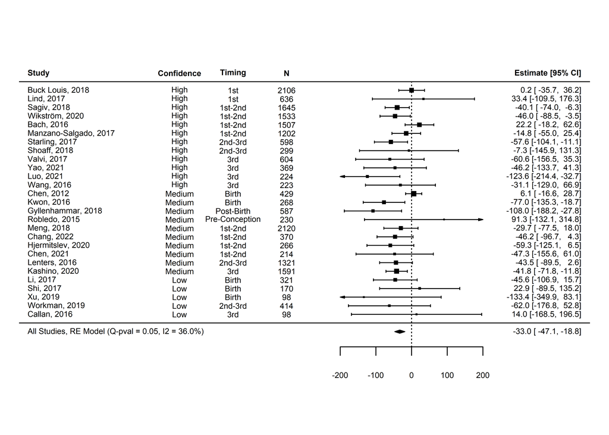

## 2.1 Leave-One-Out Analyis: Assessing heterogeneity

Results indicate that dropping Chen, 2012 leads to the lowest I2, 20.78%.

| Study | estimate | se | zval | pval | ci.lb | ci.ub | Q | Qp | tau2 | I2 | H2 |
| --- | --- | --- | --- | --- | --- | --- | --- | --- | --- | --- | --- |
| Bach, 2016 | -35.89 | 7.03 | -5.10 | 0e+00 | -49.67 | -22.11 | 32.64 | 0.14 | 309.95 | 29.06 | 1.41 |
| Buck Louis, 2018 | -35.40 | 7.45 | -4.75 | 0e+00 | -49.99 | -20.80 | 36.33 | 0.07 | 403.33 | 34.37 | 1.52 |
| Manzano-Salgado, 2017 | -34.46 | 7.62 | -4.52 | 1e-05 | -49.40 | -19.51 | 38.33 | 0.04 | 457.12 | 37.65 | 1.60 |
| Sagiv, 2018 | -32.76 | 7.70 | -4.25 | 2e-05 | -47.86 | -17.67 | 38.05 | 0.05 | 466.86 | 37.49 | 1.60 |
| Shoaff, 2018 | -33.29 | 7.29 | -4.56 | 1e-05 | -47.59 | -19.00 | 38.62 | 0.04 | 423.39 | 37.38 | 1.60 |
| Starling, 2017 | -31.59 | 7.42 | -4.26 | 2e-05 | -46.14 | -17.04 | 36.93 | 0.06 | 413.95 | 35.75 | 1.56 |
| Valvi, 2017 | -32.49 | 7.31 | -4.44 | 1e-05 | -46.83 | -18.16 | 38.21 | 0.04 | 419.75 | 37.02 | 1.59 |
| Chen, 2012 | -36.30 | 6.84 | -5.31 | 0e+00 | -49.70 | -22.89 | 28.61 | 0.28 | 226.28 | 20.78 | 1.26 |
| Gyllenhammar, 2018 | -30.75 | 7.10 | -4.33 | 1e-05 | -44.67 | -16.83 | 34.70 | 0.09 | 360.77 | 33.45 | 1.50 |
| Kwon, 2016 | -30.89 | 7.22 | -4.28 | 2e-05 | -45.04 | -16.74 | 35.77 | 0.08 | 375.41 | 33.98 | 1.51 |
| Lenters, 2016 | -32.61 | 7.56 | -4.31 | 2e-05 | -47.43 | -17.79 | 38.17 | 0.04 | 449.24 | 37.63 | 1.60 |
| Meng, 2018 | -33.45 | 7.60 | -4.40 | 1e-05 | -48.34 | -18.56 | 38.68 | 0.04 | 460.83 | 38.32 | 1.62 |
| Callan, 2016 | -33.29 | 7.27 | -4.58 | 0e+00 | -47.53 | -19.05 | 38.50 | 0.04 | 419.98 | 37.25 | 1.59 |
| Li, 2017 | -32.64 | 7.45 | -4.38 | 1e-05 | -47.24 | -18.03 | 38.33 | 0.04 | 437.52 | 37.57 | 1.60 |
| Shi, 2017 | -33.85 | 7.31 | -4.63 | 0e+00 | -48.18 | -19.52 | 37.93 | 0.05 | 424.20 | 37.35 | 1.60 |
| Xu, 2019 | -32.54 | 7.22 | -4.51 | 1e-05 | -46.69 | -18.38 | 37.76 | 0.05 | 409.79 | 36.70 | 1.58 |
| Hjermitslev, 2020 | -32.09 | 7.37 | -4.35 | 1e-05 | -46.54 | -17.65 | 37.74 | 0.05 | 419.72 | 36.69 | 1.58 |
| Kashino, 2020 | -32.57 | 7.73 | -4.21 | 3e-05 | -47.71 | -17.42 | 37.63 | 0.05 | 466.43 | 36.88 | 1.58 |
| Wikström, 2020 | -32.37 | 7.57 | -4.28 | 2e-05 | -47.21 | -17.54 | 37.87 | 0.05 | 446.20 | 37.26 | 1.59 |
| Chen, 2021 | -32.82 | 7.31 | -4.49 | 1e-05 | -47.16 | -18.48 | 38.56 | 0.04 | 423.44 | 37.29 | 1.59 |
| Lind, 2017 | -33.64 | 7.29 | -4.62 | 0e+00 | -47.93 | -19.36 | 38.01 | 0.05 | 421.93 | 37.31 | 1.60 |
| Robledo, 2015 | -33.49 | 7.25 | -4.62 | 0e+00 | -47.71 | -19.28 | 37.62 | 0.05 | 418.12 | 37.17 | 1.59 |
| Wang, 2016 | -33.11 | 7.35 | -4.51 | 1e-05 | -47.52 | -18.71 | 38.69 | 0.04 | 429.49 | 37.57 | 1.60 |
| Luo, 2021 | -30.80 | 7.08 | -4.35 | 1e-05 | -44.68 | -16.91 | 34.29 | 0.10 | 360.39 | 33.51 | 1.50 |
| Yao, 2021 | -32.77 | 7.36 | -4.46 | 1e-05 | -47.19 | -18.36 | 38.50 | 0.04 | 427.98 | 37.42 | 1.60 |
| Chang, 2022 | -32.49 | 7.51 | -4.32 | 2e-05 | -47.21 | -17.76 | 38.11 | 0.05 | 441.95 | 37.46 | 1.60 |
| Workman, 2019 | -32.61 | 7.29 | -4.47 | 1e-05 | -46.90 | -18.32 | 38.33 | 0.04 | 418.43 | 37.04 | 1.59 |

## 2.2 Publication Bias

The Egger’s regression test did not detect a statistically significant relationship between the observed effect sizes and their standard errors (p = 0.3102), indicating no evidence of funnel plot asymmetry due to publication bias. The funnel plot is displayed below.

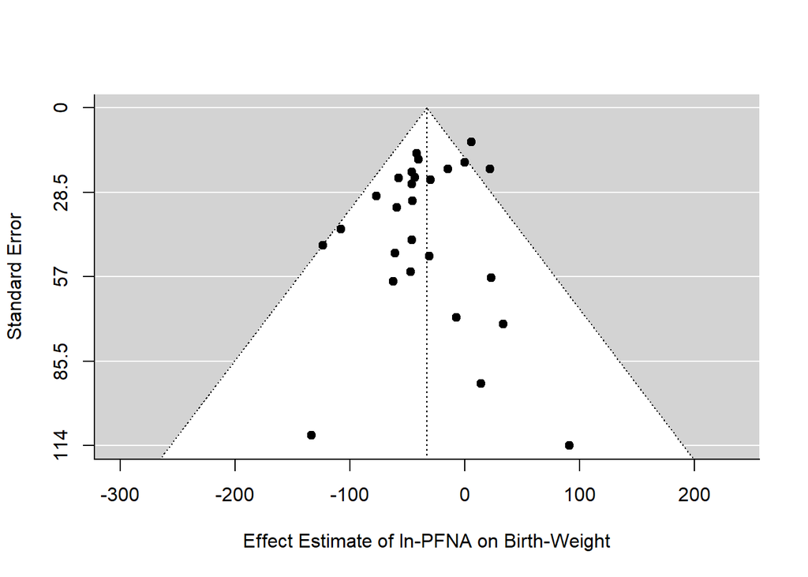

# 3 Stratified Analyses

In addition to the overall meta-analysis, the studies are also examined according to the following stratification: study confidence, sample timing.

## 3.1 Study Confidence

In this section, the studies are examined by confidence levels - low, medium, high, or medium and high combined. Pooled effects are calculated and statistical differences across strata are considered.

| Model | N | Estimate | SE | LCL | UCL | PVal | I2 | Q_PVal |
| --- | --- | --- | --- | --- | --- | --- | --- | --- |
| High | 12 | -28.0 | 10.8 | -49.0 | -6.9 | 0.01 | 38.80 | 0.11 |
| Medium | 10 | -39.2 | 11.6 | -61.8 | -16.5 | 0.00 | 48.25 | 0.02 |
| Low | 5 | -36.9 | 23.5 | -82.9 | 9.1 | 0.12 | 0.00 | 0.66 |
| High+Medium | 22 | -33.0 | 7.7 | -48.1 | -18.0 | 0.00 | 42.34 | 0.02 |

Hypothesis test results for any significant differences across strata:

- For all three levels, High, Medium and Low: p = 0.7678.
- For High + Medium and Low: p = 0.8751.

## 3.2 Sample Timing

In this approach, the strata have the following definitions:

- Early: first trimester only, mixture of first and second trimester.
- Late: second trimester only, mixture of second and third trimester, third trimester only.
- Post: at or after birth.

Pooled effects are calculated and statistical differences across strata are considered.

| Model | N | Estimate | SE | LCL | UCL | PVal | I2 | Q_PVal |
| --- | --- | --- | --- | --- | --- | --- | --- | --- |
| Early | 11 | -22.3 | 9.2 | -40.4 | -4.2 | 0.02 | 26.53 | 0.25 |
| Late | 10 | -48.4 | 9.9 | -67.7 | -29.0 | 0.00 | 0.00 | 0.91 |
| Post | 6 | -42.9 | 23.0 | -88.0 | 2.2 | 0.06 | 63.08 | 0.01 |

Hypothesis test for any differences across strata: p = 0.1469.

# 4 Sensitivity Testing

## 4.1 Re-expression to Natural Scale

## 4.2 Two-Strata Approach for the Analysis of Sample Timing

## 4.3 Continuous Approach for the ANalysis of Sample TIming